# Tidy modeling - part 2

Julia Romanowska

2021-06-19

# CHAPTER 4 - *Ames data*

The dataset contains various information on ca.3,000 properties in Ames, Iowa, USA. Look at the data:

```r
data(ames)
ames %>% glimpse()
```

```
## Rows: 2,930
## Columns: 74
## $ MS_SubClass        <fct> One_Story_1946_and_Newer_All_Styles, One_Story_1946…
## $ MS_Zoning          <fct> Residential_Low_Density, Residential_High_Density, …
## $ Lot_Frontage       <dbl> 141, 80, 81, 93, 74, 78, 41, 43, 39, 60, 75, 0, 63,…
## $ Lot_Area           <int> 31770, 11622, 14267, 11160, 13830, 9978, 4920, 5005…
## $ Street             <fct> Pave, Pave, Pave, Pave, Pave, Pave, Pave, Pave, Pav…
## $ Alley              <fct> No_Alley_Access, No_Alley_Access, No_Alley_Access, …
## $ Lot_Shape          <fct> Slightly_Irregular, Regular, Slightly_Irregular, Re…
## $ Land_Contour       <fct> Lvl, Lvl, Lvl, Lvl, Lvl, Lvl, Lvl, HLS, Lvl, Lvl, L…
## $ Utilities          <fct> AllPub, AllPub, AllPub, AllPub, AllPub, AllPub, All…
## $ Lot_Config         <fct> Corner, Inside, Corner, Corner, Inside, Inside, Ins…
## $ Land_Slope         <fct> Gtl, Gtl, Gtl, Gtl, Gtl, Gtl, Gtl, Gtl, Gtl, Gtl, G…
## $ Neighborhood       <fct> North_Ames, North_Ames, North_Ames, North_Ames, Gil…
## $ Condition_1        <fct> Norm, Feedr, Norm, Norm, Norm, Norm, Norm, Norm, No…
```

[output cut: 61 more lines]

```r
skim(ames)
```

Data summary

| Name | ames |
| --- | --- |
| Number of rows | 2930 |
| Number of columns | 74 |
| _______________________ |  |
| Column type frequency: |  |
| factor | 40 |
| numeric | 34 |
| ________________________ |  |
| Group variables | None |

**Variable type: factor**

| skim_variable | n_missing | complete_rate | ordered | n_unique | top_counts |
| --- | --- | --- | --- | --- | --- |
| MS_SubClass | 0 | 1 | FALSE | 16 | One: 1079, Two: 575, One: 287, One: 192 |
| MS_Zoning | 0 | 1 | FALSE | 7 | Res: 2273, Res: 462, Flo: 139, Res: 27 |
| Street | 0 | 1 | FALSE | 2 | Pav: 2918, Grv: 12 |
| Alley | 0 | 1 | FALSE | 3 | No_: 2732, Gra: 120, Pav: 78 |
| Lot_Shape | 0 | 1 | FALSE | 4 | Reg: 1859, Sli: 979, Mod: 76, Irr: 16 |
| Land_Contour | 0 | 1 | FALSE | 4 | Lvl: 2633, HLS: 120, Bnk: 117, Low: 60 |
| Utilities | 0 | 1 | FALSE | 3 | All: 2927, NoS: 2, NoS: 1 |
| Lot_Config | 0 | 1 | FALSE | 5 | Ins: 2140, Cor: 511, Cul: 180, FR2: 85 |
| Land_Slope | 0 | 1 | FALSE | 3 | Gtl: 2789, Mod: 125, Sev: 16 |
| Neighborhood | 0 | 1 | FALSE | 28 | Nor: 443, Col: 267, Old: 239, Edw: 194 |
| Condition_1 | 0 | 1 | FALSE | 9 | Nor: 2522, Fee: 164, Art: 92, RRA: 50 |
| Condition_2 | 0 | 1 | FALSE | 8 | Nor: 2900, Fee: 13, Art: 5, Pos: 4 |
| Bldg_Type | 0 | 1 | FALSE | 5 | One: 2425, Twn: 233, Dup: 109, Twn: 101 |
| House_Style | 0 | 1 | FALSE | 8 | One: 1481, Two: 873, One: 314, SLv: 128 |
| Overall_Cond | 0 | 1 | FALSE | 9 | Ave: 1654, Abo: 533, Goo: 390, Ver: 144 |
| Roof_Style | 0 | 1 | FALSE | 6 | Gab: 2321, Hip: 551, Gam: 22, Fla: 20 |
| Roof_Matl | 0 | 1 | FALSE | 8 | Com: 2887, Tar: 23, WdS: 9, WdS: 7 |
| Exterior_1st | 0 | 1 | FALSE | 16 | Vin: 1026, Met: 450, HdB: 442, Wd : 420 |
| Exterior_2nd | 0 | 1 | FALSE | 17 | Vin: 1015, Met: 447, HdB: 406, Wd : 397 |
| Mas_Vnr_Type | 0 | 1 | FALSE | 5 | Non: 1775, Brk: 880, Sto: 249, Brk: 25 |
| Exter_Cond | 0 | 1 | FALSE | 5 | Typ: 2549, Goo: 299, Fai: 67, Exc: 12 |
| Foundation | 0 | 1 | FALSE | 6 | PCo: 1310, CBl: 1244, Brk: 311, Sla: 49 |
| Bsmt_Cond | 0 | 1 | FALSE | 6 | Typ: 2616, Goo: 122, Fai: 104, No_: 80 |
| Bsmt_Exposure | 0 | 1 | FALSE | 5 | No: 1906, Av: 418, Gd: 284, Mn: 239 |
| BsmtFin_Type_1 | 0 | 1 | FALSE | 7 | GLQ: 859, Unf: 851, ALQ: 429, Rec: 288 |
| BsmtFin_Type_2 | 0 | 1 | FALSE | 7 | Unf: 2499, Rec: 106, LwQ: 89, No_: 81 |
| Heating | 0 | 1 | FALSE | 6 | Gas: 2885, Gas: 27, Gra: 9, Wal: 6 |
| Heating_QC | 0 | 1 | FALSE | 5 | Exc: 1495, Typ: 864, Goo: 476, Fai: 92 |
| Central_Air | 0 | 1 | FALSE | 2 | Y: 2734, N: 196 |
| Electrical | 0 | 1 | FALSE | 6 | SBr: 2682, Fus: 188, Fus: 50, Fus: 8 |
| Functional | 0 | 1 | FALSE | 8 | Typ: 2728, Min: 70, Min: 65, Mod: 35 |
| Garage_Type | 0 | 1 | FALSE | 7 | Att: 1731, Det: 782, Bui: 186, No_: 157 |
| Garage_Finish | 0 | 1 | FALSE | 4 | Unf: 1231, RFn: 812, Fin: 728, No_: 159 |
| Garage_Cond | 0 | 1 | FALSE | 6 | Typ: 2665, No_: 159, Fai: 74, Goo: 15 |
| Paved_Drive | 0 | 1 | FALSE | 3 | Pav: 2652, Dir: 216, Par: 62 |
| Pool_QC | 0 | 1 | FALSE | 5 | No_: 2917, Exc: 4, Goo: 4, Typ: 3 |
| Fence | 0 | 1 | FALSE | 5 | No_: 2358, Min: 330, Goo: 118, Goo: 112 |
| Misc_Feature | 0 | 1 | FALSE | 6 | Non: 2824, She: 95, Gar: 5, Oth: 4 |
| Sale_Type | 0 | 1 | FALSE | 10 | WD : 2536, New: 239, COD: 87, Con: 26 |
| Sale_Condition | 0 | 1 | FALSE | 6 | Nor: 2413, Par: 245, Abn: 190, Fam: 46 |

**Variable type: numeric**

| skim_variable | n_missing | complete_rate | mean | sd | p0 | p25 | p50 | p75 | p100 | hist |
| --- | --- | --- | --- | --- | --- | --- | --- | --- | --- | --- |
| Lot_Frontage | 0 | 1 | 57.65 | 33.50 | 0.00 | 43.00 | 63.00 | 78.00 | 313.00 | ▇▇▁▁▁ |
| Lot_Area | 0 | 1 | 10147.92 | 7880.02 | 1300.00 | 7440.25 | 9436.50 | 11555.25 | 215245.00 | ▇▁▁▁▁ |
| Year_Built | 0 | 1 | 1971.36 | 30.25 | 1872.00 | 1954.00 | 1973.00 | 2001.00 | 2010.00 | ▁▂▃▆▇ |
| Year_Remod_Add | 0 | 1 | 1984.27 | 20.86 | 1950.00 | 1965.00 | 1993.00 | 2004.00 | 2010.00 | ▅▂▂▃▇ |
| Mas_Vnr_Area | 0 | 1 | 101.10 | 178.63 | 0.00 | 0.00 | 0.00 | 162.75 | 1600.00 | ▇▁▁▁▁ |
| BsmtFin_SF_1 | 0 | 1 | 4.18 | 2.23 | 0.00 | 3.00 | 3.00 | 7.00 | 7.00 | ▃▂▇▁▇ |
| BsmtFin_SF_2 | 0 | 1 | 49.71 | 169.14 | 0.00 | 0.00 | 0.00 | 0.00 | 1526.00 | ▇▁▁▁▁ |
| Bsmt_Unf_SF | 0 | 1 | 559.07 | 439.54 | 0.00 | 219.00 | 465.50 | 801.75 | 2336.00 | ▇▅▂▁▁ |
| Total_Bsmt_SF | 0 | 1 | 1051.26 | 440.97 | 0.00 | 793.00 | 990.00 | 1301.50 | 6110.00 | ▇▃▁▁▁ |
| First_Flr_SF | 0 | 1 | 1159.56 | 391.89 | 334.00 | 876.25 | 1084.00 | 1384.00 | 5095.00 | ▇▃▁▁▁ |
| Second_Flr_SF | 0 | 1 | 335.46 | 428.40 | 0.00 | 0.00 | 0.00 | 703.75 | 2065.00 | ▇▃▂▁▁ |
| Gr_Liv_Area | 0 | 1 | 1499.69 | 505.51 | 334.00 | 1126.00 | 1442.00 | 1742.75 | 5642.00 | ▇▇▁▁▁ |
| Bsmt_Full_Bath | 0 | 1 | 0.43 | 0.52 | 0.00 | 0.00 | 0.00 | 1.00 | 3.00 | ▇▆▁▁▁ |
| Bsmt_Half_Bath | 0 | 1 | 0.06 | 0.25 | 0.00 | 0.00 | 0.00 | 0.00 | 2.00 | ▇▁▁▁▁ |
| Full_Bath | 0 | 1 | 1.57 | 0.55 | 0.00 | 1.00 | 2.00 | 2.00 | 4.00 | ▁▇▇▁▁ |
| Half_Bath | 0 | 1 | 0.38 | 0.50 | 0.00 | 0.00 | 0.00 | 1.00 | 2.00 | ▇▁▅▁▁ |
| Bedroom_AbvGr | 0 | 1 | 2.85 | 0.83 | 0.00 | 2.00 | 3.00 | 3.00 | 8.00 | ▁▇▂▁▁ |
| Kitchen_AbvGr | 0 | 1 | 1.04 | 0.21 | 0.00 | 1.00 | 1.00 | 1.00 | 3.00 | ▁▇▁▁▁ |
| TotRms_AbvGrd | 0 | 1 | 6.44 | 1.57 | 2.00 | 5.00 | 6.00 | 7.00 | 15.00 | ▁▇▂▁▁ |
| Fireplaces | 0 | 1 | 0.60 | 0.65 | 0.00 | 0.00 | 1.00 | 1.00 | 4.00 | ▇▇▁▁▁ |
| Garage_Cars | 0 | 1 | 1.77 | 0.76 | 0.00 | 1.00 | 2.00 | 2.00 | 5.00 | ▅▇▂▁▁ |
| Garage_Area | 0 | 1 | 472.66 | 215.19 | 0.00 | 320.00 | 480.00 | 576.00 | 1488.00 | ▃▇▃▁▁ |
| Wood_Deck_SF | 0 | 1 | 93.75 | 126.36 | 0.00 | 0.00 | 0.00 | 168.00 | 1424.00 | ▇▁▁▁▁ |
| Open_Porch_SF | 0 | 1 | 47.53 | 67.48 | 0.00 | 0.00 | 27.00 | 70.00 | 742.00 | ▇▁▁▁▁ |
| Enclosed_Porch | 0 | 1 | 23.01 | 64.14 | 0.00 | 0.00 | 0.00 | 0.00 | 1012.00 | ▇▁▁▁▁ |
| Three_season_porch | 0 | 1 | 2.59 | 25.14 | 0.00 | 0.00 | 0.00 | 0.00 | 508.00 | ▇▁▁▁▁ |
| Screen_Porch | 0 | 1 | 16.00 | 56.09 | 0.00 | 0.00 | 0.00 | 0.00 | 576.00 | ▇▁▁▁▁ |
| Pool_Area | 0 | 1 | 2.24 | 35.60 | 0.00 | 0.00 | 0.00 | 0.00 | 800.00 | ▇▁▁▁▁ |
| Misc_Val | 0 | 1 | 50.64 | 566.34 | 0.00 | 0.00 | 0.00 | 0.00 | 17000.00 | ▇▁▁▁▁ |
| Mo_Sold | 0 | 1 | 6.22 | 2.71 | 1.00 | 4.00 | 6.00 | 8.00 | 12.00 | ▅▆▇▃▃ |
| Year_Sold | 0 | 1 | 2007.79 | 1.32 | 2006.00 | 2007.00 | 2008.00 | 2009.00 | 2010.00 | ▇▇▇▇▃ |
| Sale_Price | 0 | 1 | 180796.06 | 79886.69 | 12789.00 | 129500.00 | 160000.00 | 213500.00 | 755000.00 | ▇▇▁▁▁ |
| Longitude | 0 | 1 | -93.64 | 0.03 | -93.69 | -93.66 | -93.64 | -93.62 | -93.58 | ▅▅▇▆▁ |
| Latitude | 0 | 1 | 42.03 | 0.02 | 41.99 | 42.02 | 42.03 | 42.05 | 42.06 | ▂▂▇▇▇ |

> *The [`modeldata`](https://modeldata.tidymodels.org/reference/index.html) package contains lots of other useful datasets!*

## Exploring - `Sale_Price`

The price for each house is the feature we’re going to predict.

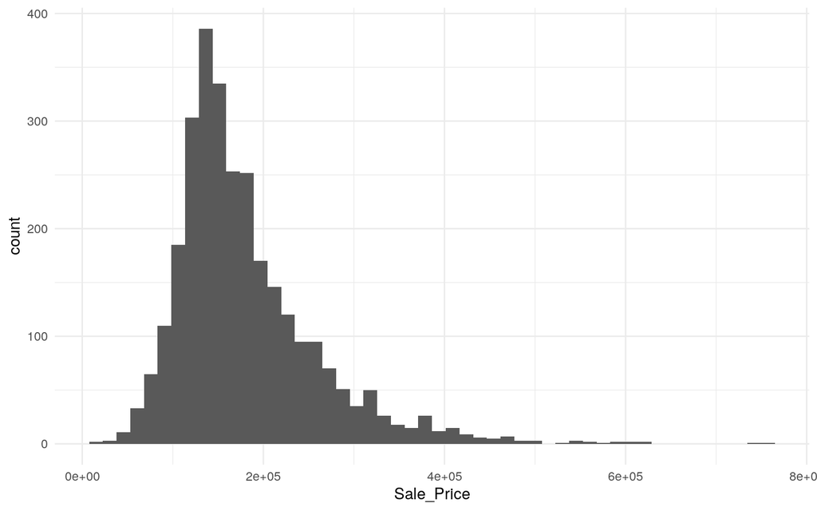

```r
ggplot(ames, aes(Sale_Price)) +
  geom_histogram(bins = 50) +
  theme_minimal()
```

Data is skewed, so we choose to log-transform it.

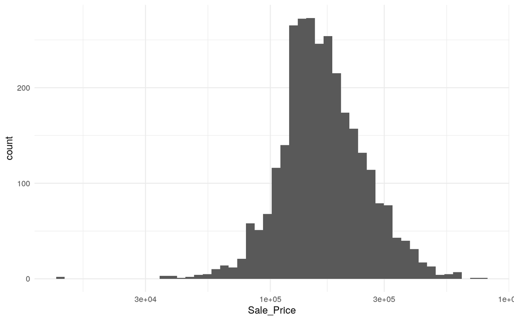

```r
ggplot(ames, aes(Sale_Price)) +
  geom_histogram(bins = 50) +
  scale_x_log10() +
  theme_minimal()
```

```r
ames <- ames %>% mutate(Sale_Price = log10(Sale_Price))
```

> **It’s important to do some exploratory analysis to decide on any preprocessing of columns!**  
> Some questions to keep in mind:  
> - any strange things about distributions of variables? - any correlation between variables? *(redundancy)* - any immediate association between variables (*predictors*) and the outcome?

# CHAPTER 5 - *Spending our data*

We need to use the data wisely by allocating its parts to different tasks and not reusing the data for different tasks!

## Splitting data

### Training

- This is usually the majority of data.
- Used to *develop the model*

### Testing

- Reserve a set for testing the best model(s).

### Validation

- Used to measure performance of trained models *before* testing.
- Mostly used with resampling methods.
- Discussed in [Chapter 10](https://www.tmwr.org/resampling.html#validation)

## How to split?

The code below splits the entire dataset into *training* and *testing* sets, with the proportions 80% and 20%, respectively.

```r
ames_split <- initial_split(ames, prop = 0.8)
ames_train <- training(ames_split)
ames_test  <-  testing(ames_split)

dim(ames_train)
```

```
## [1] 2344   74
```

```r
dim(ames_test)
```

```
## [1] 586  74
```

However, when the data is not balanced, it might be better to split using strata.

```r
ames_split <- initial_split(ames, prop = 0.80, strata = Sale_Price)
ames_train <- training(ames_split)
ames_test  <-  testing(ames_split)

dim(ames_train)
```

```
## [1] 2342   74
```

When the dataset includes a time variable, it’s adviced to use the newest data for testing. Then, one might use the `initial_time_split()` function.

> Since these functions split **by row**, it’s important to check that in our data, each row is an independent sample!

Sometimes, it might be useful to re-sample training set to check how the model reacts to various biases and class imbalance.

# CHAPTER 6 - *Recipes*

> **Feature engineering:**  
> *creating new variables (predictors) to increase effectiveness of a model*

Most often, before giving the data to the model, we need to transform some of the variables. This can be any operation that involves one or more features/variables, such as **encoding, combining, imputing, clustering**, etc. Some models *require* variables to be transformed first [(see here for a short list)](https://www.tmwr.org/pre-proc-table.html). All this can be nicely arranged and contained by using the [`recipes` package](https://recipes.tidymodels.org/).

## Preparing transformations

> **Recipes** define the necessary steps *but without* executing them!

Instead of writing *and executing* at the same time:

```r
lm(Sale_Price ~ Neighborhood + log10(Gr_Liv_Area) + Year_Built + Bldg_Type,
   data = ames)
```

we can define the necessary transformations:

```r
simple_ames <-
  recipe(Sale_Price ~ Neighborhood + Gr_Liv_Area + Year_Built + Bldg_Type,
         data = ames_train) %>%
  step_log(Gr_Liv_Area, base = 10) %>%
  step_dummy(all_nominal_predictors())
simple_ames
```

```
## Data Recipe
##
## Inputs:
##
##       role #variables
##    outcome          1
##  predictor          4
##
## Operations:
##
## Log transformation on Gr_Liv_Area
## Dummy variables from all_nominal_predictors()
```

**ADVANTAGES:**

- one recipe can be re-used for different models
- much broader range of transformations to choose from than when using `formula`
- compact syntax (several selectors are pre-defined, such as `all_nominal()`)
- all data preprocessing is kept in one R object

## Executing transformations

To execute the steps of the recipe, use `prep` function on training dataset:

```r
simple_ames <- prep(simple_ames, training = ames_train)
simple_ames
```

```
## Data Recipe
##
## Inputs:
##
##       role #variables
##    outcome          1
##  predictor          4
##
## Training data contained 2342 data points and no missing data.
##
## Operations:
##
## Log transformation on Gr_Liv_Area [trained]
## Dummy variables from Neighborhood, Bldg_Type [trained]
```

> Be careful with the order of the steps, since some of them change and/or delete columns in the dataset!

> `prep` returns a recipe object

## Training

The last step is to `bake`!

```r
test_ex <- bake(simple_ames, new_data = ames_test)
names(test_ex) %>% head()
```

```
## [1] "Gr_Liv_Area"                "Year_Built"
## [3] "Sale_Price"                 "Neighborhood_College_Creek"
## [5] "Neighborhood_Old_Town"      "Neighborhood_Edwards"
```

We can always choose which variables to return if the dataset is very large.

```r
bake(simple_ames, ames_test, starts_with("Neighborhood_"))
```

```
## # A tibble: 588 x 28
##    Neighborhood_College… Neighborhood_Old_… Neighborhood_Edw… Neighborhood_Some…
##                    <dbl>              <dbl>             <dbl>              <dbl>
##  1                     0                  0                 0                  0
##  2                     0                  0                 0                  0
##  3                     0                  0                 0                  0
##  4                     0                  0                 0                  0
##  5                     0                  0                 0                  0
##  6                     0                  0                 0                  0
##  7                     0                  0                 0                  0
##  8                     0                  0                 0                  0
##  9                     0                  0                 0                  0
## 10                     0                  0                 0                  1
## # … with 578 more rows, and 24 more variables:
## #   Neighborhood_Northridge_Heights <dbl>, Neighborhood_Gilbert <dbl>,
## #   Neighborhood_Sawyer <dbl>, Neighborhood_Northwest_Ames <dbl>,
## #   Neighborhood_Sawyer_West <dbl>, Neighborhood_Mitchell <dbl>,
## #   Neighborhood_Brookside <dbl>, Neighborhood_Crawford <dbl>,
## #   Neighborhood_Iowa_DOT_and_Rail_Road <dbl>, Neighborhood_Timberland <dbl>,
## #   Neighborhood_Northridge <dbl>, Neighborhood_Stone_Brook <dbl>,
## #   Neighborhood_South_and_West_of_Iowa_State_University <dbl>,
## #   Neighborhood_Clear_Creek <dbl>, Neighborhood_Meadow_Village <dbl>,
## #   Neighborhood_Briardale <dbl>, Neighborhood_Bloomington_Heights <dbl>,
## #   Neighborhood_Veenker <dbl>, Neighborhood_Northpark_Villa <dbl>,
## #   Neighborhood_Blueste <dbl>, Neighborhood_Greens <dbl>,
## #   Neighborhood_Green_Hills <dbl>, Neighborhood_Landmark <dbl>,
## #   Neighborhood_Hayden_Lake <dbl>
```

Moreover, if we want to extract the trained data, we can nullify the `new_data` argument:

```r
bake(simple_ames, new_data = NULL) %>% dim()
```

```
## [1] 2342   35
```

```r
dim(ames_train)
```

```
## [1] 2342   74
```

## Encoding

There are several ways to encode qualitative data into numeric. Sometimes, it might be good to pre-define factor levels. Here are some of the functions that can be useful:

- `step_unknown()` - changes all missing data to a certain level;
- `step_novel()` - adds a level that might not be in the training data;
- `step_other()` - combines certain labels into one level “other”;
- `step_dummy()` - performs a `pivot_wider` operation, creating binary indicators for all but 1 levels of the qual.var.; the new colums are named using the pattern `ColumnName_LevelName`, so that it’s easy to catch those afterward, e.g., using `starts_with("Neighborhood_")`.

There are also more sophisticated methods for encoding, e.g.:

- **feature hashing** - encodes a variable into a pre-defined set of levels; this might sometimes result in assigning different values to the same level; needs to be use with caution;
- **effect encodings/likelihood encodings** - replace the variable with a single numeric column measuring the *effect* of the data, e.g., mean of the outcome per category; this can lead to overfitting!
- `step_unorder()` - converts to a regular factor (e.g., months’ names);
- `step_ordinalscore()` - maps specific values to each level.

### TASK

Based on the distribution of the houses across neighborhoods, modify the recipe to clump the smallest 1% of the neighborhood categories into one category “other”.

## Interaction terms

It is good to explore relationships between various predictors to check whether there might be an interaction involved.

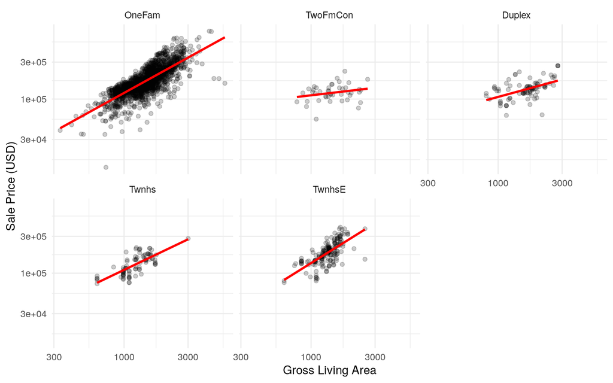

```r
ggplot(ames_train, aes(x = Gr_Liv_Area, y = 10^Sale_Price)) +
  geom_point(alpha = .2) +
  facet_wrap(~ Bldg_Type) +
  geom_smooth(method = lm, formula = y ~ x, se = FALSE, col = "red") +
  scale_x_log10() +
  scale_y_log10() +
  labs(x = "Gross Living Area", y = "Sale Price (USD)") +
  theme_minimal()
```

In `recipes`, there is a `step_interact()` function that combines specific columns (*after* encoding the qualitative variables!) using `dplyr`-like selectors.

```r
simple_ames <-
  recipe(Sale_Price ~ Neighborhood + Gr_Liv_Area + Year_Built + Bldg_Type,
         data = ames_train) %>%
  step_log(Gr_Liv_Area, base = 10) %>%
  step_other(Neighborhood, threshold = 0.01) %>%
  step_dummy(all_nominal_predictors()) %>%
  # Gr_Liv_Area is on the log scale from a previous step
  step_interact( ~ Gr_Liv_Area:starts_with("Bldg_Type_"))
```

> This produces columns named using the pattern `var_1_x_var_2`.

## Skipping steps

> **Do not transform outcome columns!** These are separated inside a recipe and can’t be accessed.

Some steps should be done either before defining the recipe (like transformation of outcome columns) or only during the training stage (like subsampling an imbalanced dataset). Each recipe function has a `skip` argument, which tells whether or not to skip this step when `baking`.

> The `themis` package has several useful functions to deal with imbalanced datasets, e.g., `step_downsample()`

## Other useful `step` functions

### `step_ns()`

Creates a *natural spline*

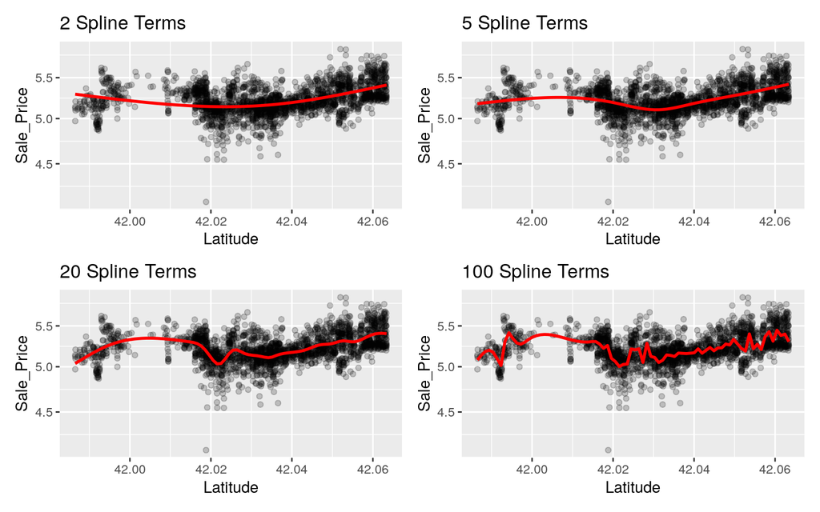

```r
library(patchwork)
library(splines)

plot_smoother <- function(deg_free) {
  ggplot(ames_train, aes(x = Latitude, y = Sale_Price)) +
    geom_point(alpha = .2) +
    scale_y_log10() +
    geom_smooth(
      method = lm,
      formula = y ~ ns(x, df = deg_free),
      col = "red",
      se = FALSE
    ) +
    ggtitle(paste(deg_free, "Spline Terms"))
}

( plot_smoother(2) + plot_smoother(5) ) / ( plot_smoother(20) + plot_smoother(100) )
```

### `step_pca()`

Creates a new variable that contains a PC of several other.

*In the Ames data, there are several predictors that measure size of the property, such as the total basement size (`Total_Bsmt_SF`), size of the first floor (`First_Flr_SF`), the gross living area (`Gr_Liv_Area`), and so on.*

We can combine those with:

```r
# Use a regular expression to capture house size predictors:
step_pca(matches("(SF$)|(Gr_Liv)"))
```

### `step_mutate()` and `step_mutate_at()`

Analogous to the [`dplyr` functions](https://dbplyr.tidyverse.org/reference/mutate.tbl_lazy.html), these allow for any transformation.

### `textrecipes` package

[`textrecipes` package](https://textrecipes.tidymodels.org/index.html) includes special `step` functions adjusted for handling text data.

## TASK

Add a step in the recipe that creates a natural spline using `Latitude` data.

## Using a `recipe` with traditional modeling

```r
ames_rec_prepped <- prep(ames_rec)
ames_train_prepped <- bake(ames_rec_prepped, new_data = NULL)
ames_test_prepped <- bake(ames_rec_prepped, ames_test)

# Fit the model; Note that the column Sale_Price has already been
# log transformed.
lm_fit <- lm(Sale_Price ~ ., data = ames_train_prepped)
```

We get a `lm` model object as a result:

```r
class(lm_fit)
```

```
## [1] "lm"
```

```r
names(lm_fit)
```

```
##  [1] "coefficients"  "residuals"     "effects"       "rank"
##  [5] "fitted.values" "assign"        "qr"            "df.residual"
##  [9] "xlevels"       "call"          "terms"         "model"
```

The [`broom` package](https://broom.tidymodels.org/) helps clean up the various outputs from different modeling functions into one consist `tibble` output.

```r
glance(lm_fit)
```

```
## # A tibble: 1 x 12
##   r.squared adj.r.squared  sigma statistic p.value    df logLik    AIC    BIC
##       <dbl>         <dbl>  <dbl>     <dbl>   <dbl> <dbl>  <dbl>  <dbl>  <dbl>
## 1     0.830         0.825 0.0745      156.       0    71  2795. -5445. -5025.
## # … with 3 more variables: deviance <dbl>, df.residual <int>, nobs <int>
```

```r
# return the model coefficients nicely formatted
tidy(lm_fit)
```

```
## # A tibble: 72 x 5
##    term                            estimate std.error statistic   p.value
##    <chr>                              <dbl>     <dbl>     <dbl>     <dbl>
##  1 (Intercept)                     -0.231    0.281       -0.820 4.12e-  1
##  2 Gr_Liv_Area                      0.644    0.0149      43.4   1.02e-299
##  3 Year_Built                       0.00178  0.000131    13.6   1.17e- 40
##  4 Neighborhood_College_Creek      -0.0101   0.0332      -0.305 7.60e-  1
##  5 Neighborhood_Old_Town           -0.0496   0.0122      -4.07  4.77e-  5
##  6 Neighborhood_Edwards            -0.0930   0.0269      -3.46  5.48e-  4
##  7 Neighborhood_Somerset            0.0708   0.0181       3.92  9.28e-  5
##  8 Neighborhood_Northridge_Heights  0.133    0.0273       4.89  1.10e-  6
##  9 Neighborhood_Gilbert             0.0315   0.0210       1.50  1.35e-  1
## 10 Neighborhood_Sawyer             -0.114    0.0256      -4.45  8.92e-  6
## # … with 62 more rows
```

Finally, we can predict:

```r
predict(lm_fit, ames_test_prepped) %>% head()
```

```
##        1        2        3        4        5        6
## 5.305471 5.658622 5.044864 5.190953 5.458330 5.324659
```

**BONUS** `tidy` can also be called on a recipe:

```r
tidy(ames_rec)
```

```
## # A tibble: 5 x 6
##   number operation type     trained skip  id
##    <int> <chr>     <chr>    <lgl>   <lgl> <chr>
## 1      1 step      log      FALSE   FALSE log_NTpEv
## 2      2 step      other    FALSE   FALSE other_0uPVA
## 3      3 step      dummy    FALSE   FALSE dummy_Wh8J2
## 4      4 step      interact FALSE   FALSE interact_waYdX
## 5      5 step      ns       FALSE   FALSE ns_BBK7v
```

## Column roles

When preparing the training dataset with `prep`, only the columns that have a pre-assigned role will be kept. There are two roles that are automatically assigned when constructing a formula: **outcome** and **predictors**. If we want to keep some other columns in the training and testing datasets, we need to give them some role - this can be achieved by using `add_role()`, `remove_role()`, and `update_role()`, or by setting the `role` argument inside a `step` function.

```r
ames_rec %>% update_role(Address, new_role = "street address")
```

> The role name can be any character string. Columns can also have multiple roles.

# CHAPTER 7 - *Parsnip*

Traditionally, in base R, fitting a model would require finding an adequate R package, adapting the input data to its requirements (matrix, data.frame, which format for outcome vs. predictors, etc.), and checking the documentation of the function to create a valid function call (using a formula vs. giving the outcome and predictors as vectors, naming the arguments correctly, etc.).

The [`parsnip` package](https://parsnip.tidymodels.org/) aims to unify it by wrapping calls to various other packages in a single function, `fit` (or `fit_xy`).

```r
lm_model <-
  linear_reg() %>%
  set_engine("lm")

lm_form_fit <-
  lm_model %>%
  fit(Sale_Price ~ Longitude + Latitude, data = ames_train)

lm_xy_fit <-
  lm_model %>%
  fit_xy(
    x = ames_train %>% select(Longitude, Latitude),
    y = ames_train %>% pull(Sale_Price)
    )

lm_form_fit
```

```
## parsnip model object
##
## Fit time:  2ms
##
## Call:
## stats::lm(formula = Sale_Price ~ Longitude + Latitude, data = data)
##
## Coefficients:
## (Intercept)    Longitude     Latitude
##    -310.256       -2.062        2.912
```

```r
lm_xy_fit
```

```
## parsnip model object
##
## Fit time:  2ms
##
## Call:
## stats::lm(formula = ..y ~ ., data = data)
##
## Coefficients:
## (Intercept)    Longitude     Latitude
##    -310.256       -2.062        2.912
```

> The `fit_xy()` function always passes the data as-is to the underlying model function. It will not create dummy variables before doing so.

The overall steps for fitting a model with `parsnip` are as follows:

1. specify the type of model (maths)
2. specify which package to use (*set engine*)
3. *(not always)* specify the mode: **regression** or **classification**

**ADVANTAGES:**

- these steps can be done without refering to data

```r
linear_reg() %>% set_engine("lm")
```

```
## Linear Regression Model Specification (regression)
##
## Computational engine: lm
```

```r
linear_reg() %>% set_engine("glmnet")
```

```
## Linear Regression Model Specification (regression)
##
## Computational engine: glmnet
```

```r
linear_reg() %>% set_engine("stan")
```

```
## Linear Regression Model Specification (regression)
##
## Computational engine: stan
```

- apply the same fitting procedure on various datasets
- when switching between packages, only the name of the package changes in the code
- argument names are consistent and understandable
- results are always named in a consistent way

## `parsnip` object

The output of `fit` is a `parsnip` model object, which contains various elements, related to the data, model, and fitting results.

```r
lm_form_fit %>% pluck("fit")
```

```
##
## Call:
## stats::lm(formula = Sale_Price ~ Longitude + Latitude, data = data)
##
## Coefficients:
## (Intercept)    Longitude     Latitude
##    -310.256       -2.062        2.912
```

With base R, one would get the information about the model results as follows:

```r
(base_res <- lm_form_fit %>% pluck("fit") %>% summary())
```

```
##
## Call:
## stats::lm(formula = Sale_Price ~ Longitude + Latitude, data = data)
##
## Residuals:
##      Min       1Q   Median       3Q      Max
## -1.02084 -0.09724 -0.01740  0.09994  0.57713
##
## Coefficients:
##              Estimate Std. Error t value Pr(>|t|)
## (Intercept) -310.2557    14.6859  -21.13   <2e-16 ***
## Longitude     -2.0616     0.1308  -15.76   <2e-16 ***
## Latitude       2.9124     0.1825   15.96   <2e-16 ***
## ---
## Signif. codes:  0 '***' 0.001 '**' 0.01 '*' 0.05 '.' 0.1 ' ' 1
##
## Residual standard error: 0.1621 on 2339 degrees of freedom
## Multiple R-squared:  0.1719, Adjusted R-squared:  0.1712
## F-statistic: 242.8 on 2 and 2339 DF,  p-value: < 2.2e-16
```

```r
coef(base_res)
```

```
##                Estimate Std. Error   t value     Pr(>|t|)
## (Intercept) -310.255727 14.6859321 -21.12605 8.227707e-91
## Longitude     -2.061597  0.1307906 -15.76257 2.817305e-53
## Latitude       2.912419  0.1824514  15.96271 1.585297e-54
```

This returns a matrix of numeric values with column names for the type of estimate and row names for the predictors. However, again, the results of different methods would contain different names of columns. Moreover, the name `Pr(>|t|)` is not a valid variable name in R, so it’s difficult to use it.

Using `broom` solves this:

```r
tidy(lm_form_fit)
```

```
## # A tibble: 3 x 5
##   term        estimate std.error statistic  p.value
##   <chr>          <dbl>     <dbl>     <dbl>    <dbl>
## 1 (Intercept)  -310.      14.7       -21.1 8.23e-91
## 2 Longitude      -2.06     0.131     -15.8 2.82e-53
## 3 Latitude        2.91     0.182      16.0 1.59e-54
```

## `predict`

Calling `predict()` on a `parsnip` object gives different results than when calling it on a base-R model.

```r
predict(lm_form_fit, new_data = ames_test)
```

```
## # A tibble: 588 x 1
##    .pred
##    <dbl>
##  1  5.28
##  2  5.26
##  3  5.24
##  4  5.23
##  5  5.32
##  6  5.30
##  7  5.29
##  8  5.29
##  9  5.29
## 10  5.29
## # … with 578 more rows
```

- result is always a `tibble`
- no.of rows is always the same as no.of rows in the input
- column names are predictable

Using the `type` argument of `predict()`, we can change the columns of the output:

```r
predict(lm_form_fit, new_data = ames_test, type = "conf_int")
```

```
## # A tibble: 588 x 2
##    .pred_lower .pred_upper
##          <dbl>       <dbl>
##  1        5.27        5.30
##  2        5.25        5.28
##  3        5.23        5.25
##  4        5.22        5.24
##  5        5.31        5.33
##  6        5.29        5.31
##  7        5.28        5.31
##  8        5.28        5.30
##  9        5.28        5.30
## 10        5.28        5.29
## # … with 578 more rows
```

Thus, we can e.g., easily merge the predictions with the original data!

### TASK 1

Check in the documentation of the `predict.model_fit` function other types of output and then fill in the dots below: using `bind_cols()` function, attach the predicted values and the CI to the original data `ames_test`.

```r
# for simplicity, we select only some of the many columns
ames_test %>%
  select(Sale_Price, Year_Built, Bldg_Type, Gr_Liv_Area) %>%
  ...
```

### TASK 2

Let’s change the model to *decision tree*, predict, and check the results:

```r
# define the model fit:
tree_fit <- decision_tree(min_n = 2) %>%
  # set engine 'rpart'
  ... %>%
  # set mode: 'regression'
  ... %>%
  # fit the model using the same formula as previously
  ...
```

Finally, attach the predictions to the original testing dataset, as above:

```r
ames_test %>%
  select(Sale_Price, Year_Built, Bldg_Type, Gr_Liv_Area) %>%
  ...
```

## Other packages

`parsnip` package implements interface to the most popular statistical modeling packages and there are other, specialized packages, similar to `parsnip` that have interfaces to other modeling procedures. The list of all the possible interfaces are [on the tidymodels website](https://www.tidymodels.org/find/).

## Help creating the code

The [`usemodels` package](https://usemodels.tidymodels.org/) creates the code that includes recipe, model, and fitting with one function call!

```r
library(usemodels)

use_xgboost(Sale_Price ~ Neighborhood + Gr_Liv_Area + Year_Built + Bldg_Type +
              Latitude + Longitude,
            data = ames_train,
            # Don't create the model tuning code:
            tune = FALSE,
            # Add comments explaining some of the code:
            verbose = TRUE)
```

```
## xgboost_recipe <-
##   recipe(formula = Sale_Price ~ Neighborhood + Gr_Liv_Area + Year_Built + Bldg_Type +
##     Latitude + Longitude, data = ames_train) %>%
##   step_novel(all_nominal(), -all_outcomes()) %>%
##   ## This model requires the predictors to be numeric. The most common
##   ## method to convert qualitative predictors to numeric is to create
##   ## binary indicator variables (aka dummy variables) from these
##   ## predictors. However, for this model, binary indicator variables can be
##   ## made for each of the levels of the factors (known as 'one-hot
##   ## encoding').
##   step_dummy(all_nominal(), -all_outcomes(), one_hot = TRUE) %>%
##   step_zv(all_predictors())
##
## xgboost_spec <-
##   boost_tree() %>%
##   set_mode("regression") %>%
##   set_engine("xgboost")
##
## xgboost_workflow <-
##   workflow() %>%
##   add_recipe(xgboost_recipe) %>%
##   add_model(xgboost_spec)
```

`parsnip` package gives also a handy GUI tool:

```r
parsnip:::parsnip_addin()
```